# Avaliação I (Soluções)

> Olá pessoal! Essa é uma possível solulçao de nossa [Avaliação I](https://icaro-freire.github.io/estat_2020.1/01_avaliacao_estatistica.html). Logicamente, existem muitas soluções que chegam à mesma resposta.

## 0. Antes de começar …

Para começarmos, vamos carregar o pacote *tidyverse* para nossas análises:

```r
library(tidyverse)
```

Além disso, por uma questão didática, vamos reescrever as questões em **negrito** e as respostas virão logo após cada pergunta.

## 1. Dataset “peixes_rio_madeira.csv”

Agora, vamos carregar o primeiro conjunto de dados para responder as questões sobre o *dataset* `peixes_rio_madeira.csv`.

```r
peixes <- read_csv("dados/peixes_rio_madeira.csv")
```

$\#\text{dica}$. Sempre dê um `glimpse()` e um `view()` para conhecer melhor seus *datasets*.

### Questão 01

**Considerando a variável `ordem`, responda:**

1. **Faça uma distribuição de frequência da variável `ordem`, ordenando os valores numéricos de forma crescente.**

`(Solução)` Para fazer a distribuição de frequência, vamos selecionar a variável `ordem` e contar os seus agrupamentos.

```r
peixes %>%
  group_by(ordem) %>%
  select(ordem) %>%
  summarise(
    n = n()
  ) %>%
  arrange(n)
```

| ordem | n |
| --- | --- |
| Lepidosireniformes | 2 |
| Pleuronectiformes | 2 |
| Beloniformes | 5 |
| Não identificado | 17 |
| Myliobatiformes | 41 |
| Osteoglossiformes | 433 |
| Gymnotiformes | 693 |
| Acanthuriformes | 1602 |
| Cichliformes | 1947 |
| Clupeiformes | 2821 |

[output cut: 2 more lines]

Uma maneira mais concisa é usarmos a função `count()` e fazermos:

```r
peixes %>%
  group_by(ordem) %>%
  count(ordem) %>%
  arrange(n)
```

2. **Qual `ordem` de peixe foi a mais identificada? Quantas foram as observações?**

`(Solução)` Pela tabela anterior, ordenada de forma crescente, a última observação é a mais identificada, a saber, *Characiformes*.

3. **Quantos não foram identificados na variável `ordem`?**

`(Solução)` Ainda pela tabela, encontramos que em 17 peixes não foi identificada a `ordem`.

### Questão 02

**Dentre os peixes que foram coletados da bacia do “Rio Guaporé”, após a seleção da `ordem` e do `peso_g`, bem como a eliminação dos elementos não identificados; deseja-se comparar qual das ordens é a mais *homogênea*, no que se refere ao seu peso.** **Para isso, é necessário comparar a variabilidade do `peso_g` em relação à média. Se a média é igual em cada ordem, usamos o *desvio padrão*.** **Todavia, se a média em cada ordem é diferente, precisamos padronizar essa medida; e, nesse caso, usamos o *coeficiente de variação* (cv), em porcentagem.** **Quanto menor a porcentagem do `cv`, mais homogênea é a distribuição do `peso_g`.** **Define-se:**
$$\text{cv} = \frac{\text{desvio padrão}}{média} \cdot 100$$

1. **Qual medida de variabilidade é mais adequada para essa situação?**
2. **Determine qual das ordens dos peixes da bacia do Rio Guaporé possui distribuição de peso mais homogênea.**

`(Solução)` O código abaixo expressa as condições necessárias para responder aos itens acima.

```r
peixes %>%
  filter(bacia == "Rio Guaporé") %>% # filtrando a bacia Guaporé
  select(ordem, peso_g) %>%          # selecionando a `ordem` e o `peso_g`
  group_by(ordem) %>%                # agrupando pela `ordem`
  drop_na()                          # retirando os dados ausentes/não identificados
```

1. Para responder ao primeiro item, precisamos sumarizar os dados acima em relação à média e observarmos se são “iguais” (ou suficientemente próximos)

```r
peixes %>%
  filter(bacia == "Rio Guaporé") %>%
  select(ordem, peso_g) %>%
  group_by(ordem) %>%
  drop_na() %>%
  summarise(
    media = mean(peso_g)             # sumarizando a média de cada ordem
  )
```

| ordem | media |
| --- | --- |
| Acanthuriformes | 198.00000 |
| Characiformes | 65.84589 |
| Cichliformes | 178.80000 |
| Clupeiformes | 300.14815 |
| Gymnotiformes | 80.61111 |
| Siluriformes | 92.32534 |

Como as *médias* são bem distintas, a medida de variabilidade mais adequada para esse caso é o *coeficiente de variação*.

2. Para calcularmos o `cv`, precisamos do *desvio padrão* e da *média*. Para isso, vamos sumarizar esses dados e inserir a fórmula do `cv`. Além disso, vamos arranjar esses dados de forma crencente com a função `arrange()`:

```r
peixes %>%
  filter(bacia == "Rio Guaporé") %>%
  select(ordem, peso_g) %>%
  group_by(ordem) %>%
  drop_na() %>%
  summarise(
    media         = mean(peso_g),
    desvio_padrao = sd(peso_g),
    cv            = (desvio_padrao/media) * 100
  ) %>%
  arrange(cv)
```

| ordem | media | desvio_padrao | cv |
| --- | --- | --- | --- |
| Clupeiformes | 300.14815 | 234.82886 | 78.23765 |
| Gymnotiformes | 80.61111 | 79.83779 | 99.04068 |
| Acanthuriformes | 198.00000 | 249.60168 | 126.06146 |
| Cichliformes | 178.80000 | 242.39976 | 135.57033 |
| Characiformes | 65.84589 | 106.35040 | 161.51411 |
| Siluriformes | 92.32534 | 206.16689 | 223.30477 |

Veja que interessante: embora o desvio padrão da ordem *Clupeiformes* não seja o menor dentre os analisados, essa é a classe que representa a maior homogeneidade no peso, visto que possui o menor *coeficiente de variação*.

### Questão 03

**No que se refere à variável `sexo`, recodifique-a (coloque o nomo nome como `sexo_recode`) para que você possa filtrar aspenas os sexos “Macho” e “Fêmea”, depois responda:**

1. **Qual o aumento, em porcentagem, devemos dar à quantidade de machos para que possua a mesma quantidade referente às fêmeas?**
2. **Selecione as variáveis `peso_g` e `sexo_recode`, dentre os peixes identificados por “Macho” e “Fêmea”, qual o sexo do peixe com maior peso?**

`(Solução)` Para recodificar a variável `sexo` precisamos saber quais são os distintos elementos que os compõe. Para isso, usamos a função `distinct()`, como mostra o código:

```r
peixes %>%
  distinct(sexo)
```

| sexo |
| --- |
| Fêmea |
| Macho |
| Não coletado |
| fêmea |

Note que existem quatro possibilidades, mas a terceira, “Não coletado”, não nos interessa no momento. Vemos, então, que a nossa dificuldade está nas variações “Fêmea” e “fêmea”, que são a mesma coisa. Por isso, usaremos a função `mutate()` para essas mudanças, bem como atribuiremos às mudanças à própria variável `peixes`:

```r
peixes <- peixes %>%      # salvando as mudanças em `peixes`
  mutate(                 # criando uma nova coluna com as mudanças em questão
    sexo_recode = recode( # `sexo_recode` é a nova variável que será recodificada
      sexo,               # variável antiga
      "fêmea" = "Fêmea"   # recodificando
    )
  )
```

1. Para sabermos a porcentagem de macho e fêmea, vamos criar uma distribuição de frequência, selecionando a variável `sexo_recode`; depois filtrando os sexos desejados, depois agrupando-os e, por fim, contando-os, como mostra o código seguinte:

```r
peixes %>%
  select(sexo_recode) %>%                         # selecionando a variável codificada
  filter(sexo_recode == c("Macho", "Fêmea")) %>%  # filtrando os sexos "Macho" e "Fêmea"
  group_by(sexo_recode) %>%                       # agrupando
  count()                                         # contando
```

| sexo_recode | n |
| --- | --- |
| Fêmea | 14092 |
| Macho | 10717 |

Observe que o número de Machos é menor do que o número de Fêmeas, por isso tem sentido pensarmos numa porcentagem de aumento do número de Machos. Consideremos $m$, $f$ e $x$, respectivamente: número de machos, número de fêmeas e a porcentagem desejada. Então, queremos:
$$m \cdot x + m = f.$$
Ou, especificamente: $x = f/m - 1$. Daí, $x = 14092/10717 -1 = 0.3149202$. Ou seja, aproximadamente $31.5 \%$.

2. Existem muitas formas de fazer essa questão, dentre elas, podemos usar a função `arrange()` de forma decrescente `arrange(desc(...))`, como no código abaixo:

```r
peixes %>%
  select(sexo_recode, peso_g) %>%
  filter(sexo_recode == c("Macho", "Fêmea")) %>%
  arrange(desc(peso_g))
```

Mas, como você pode verificar, serão muitas linhas desnecessárias. Então, podemos usar a função `top_n()` e selecionarmos a que possui o maior peso.

```r
peixes %>%
  select(sexo_recode, peso_g) %>%
  filter(sexo_recode == c("Macho", "Fêmea")) %>%
  top_n(1, peso_g)                                # selecionando o 1º maior
```

| sexo_recode | peso_g |
| --- | --- |
| Fêmea | 14600 |

Portanto, o sexo do peixe que possui o maior peso é Fêmea. Tal peixe, possui $14600$ gramas!!!

### Questão 04

**Quantos peixes carnívoros eram machos?**

`(Solução)` Ora, para sabermos se o peixe era “carnívoro”, precisamos selecionar a variável `habito_alimentar`. Além disso, vamos precisar filtrar o sexo “Macho” **e** que são “Carnívoros”. Por fim, contamos as linhas. Então, podemos fazer:

```r
peixes %>%
  select(habito_alimentar, sexo) %>%                            # selecionando as variáveis
  filter(sexo == "Macho" & habito_alimentar == "Carnívoro") %>% # filtrando a interseção
  count()                                                       # contando
```

| n |
| --- |
| 8552 |

Portanto, exitem 8552 peixes que eram macho e carnívoros.

## 2. *Dataset* “contracheque.csv”

Vamos atribuir à variável `salario` o carregamento dos dados do *dataset* `contracheque.csv`.

```r
salario <- read_csv("dados/contracheque.csv")
```

### Questão 05

**Qual o maior rendimento líquido registrado nesse *dataset*?**

`(Solução)` Basta usar a função `top_n()` e colocarmos o argumento para sabermos qual o maior (o 1º):

```r
salario %>%
  select(rendimento_liquido) %>%  # selecionando a variável
  top_n(1)                        # escolhendo o 1º, o maior
```

| rendimento_liquido |
| --- |
| 7267672 |

Portanto, o maior rendimento líquido do *dataset* é de (pasmem) $\text{R}\$ 7267672$ (Sete milhões, duzentos e sessenta e sete mil, seiscentos e setenta e dois reais !!!!!!!).

**Obs.:** Quantos anos você precisaria trabalhar, juntando todo seu salário, para ganhar o que esse magistrado ganhou em um mês?

### Questão 06

**Sabendo-se que o teto constitucional do funcionalismo público é de $\text{R}\$ 39.293,32$, determine quantos magistrados receberam acima desse valor.**

1. **Quantos magistrados ganharam acima de $\text{R}\$ 100.000,00$ ?**
2. **Qual `tribunal` possui maior variabilidade?**

`(Solução)` A ideia do primeiro questionamento é filtrarmos o rendimento líquido dos magistrados que recebem acima do valor estipulado:

```r
salario %>%
  select(rendimento_liquido) %>%             # seleciona a variável
  filter(rendimento_liquido > 39293.32) %>%  # filtra os valores maiores do que 39293.32
  count()                                    # conta quantas linhas possui
```

| n |
| --- |
| 37334 |

1. De maneira análoga, temos:

```r
salario %>%
  select(rendimento_liquido) %>%
  filter(rendimento_liquido > 100000) %>%
  count()
```

| n |
| --- |
| 1136 |

Logo, 1136 (mil cento e trinta e seis) magistrados receberam, de forma líquida (ou seja, depois de todos os descontos), acima de 100000 (cem mil reais).

2. Para sabermos a maior variabilidade, vamos analisar a média salarial dos tribunais. Como vimos, isso é importante para escolhermos a medida de variabilidade que mais se adequa (desvio padrão ou coeficiente de variação). Obviamente, será necessário um agrupamento na variável `tribunal`

```r
salario %>%
  group_by(tribunal) %>%
  select(tribunal, rendimento_liquido) %>%
  summarise(
    media = mean(rendimento_liquido, na.rm = TRUE)
  )
```

Você poderá verificar que as médias são bem distintas. Portanto, a escolha do coeficiente de variação é o mais adequado (como na maioria dos casos).

```r
salario %>%
  group_by(tribunal) %>%
  select(tribunal, rendimento_liquido) %>%
  drop_na() %>%
  summarise(
    dp_salario    = sd(rendimento_liquido),
    media_salario = mean(rendimento_liquido),
    cv_salario = (dp_salario/media_salario) * 100
  ) %>%
  top_n(1, cv_salario)
```

| tribunal | dp_salario | media_salario | cv_salario |
| --- | --- | --- | --- |
| Tribunal Regional do Trabalho da 7ª Região (CE) | 389452.7 | 54658.72 | 712.5171 |

Logo, o *Tribunal Regional do Trabalho da 7ª Região (CE)* é o que possui maior variabilidade no rendimento líquido.

## 3. *Dataset* “cursos_prouni.csv”

Lendo os dados e atribuindo à variável `cursos` tal importação:

```r
cursos <- read_csv("dados/cursos-prouni.csv")
```

### Questão 07

**O gráfico abaixo são os *boxplots* da varivável `nota_integral_ampla` agrupadas pelo `turno`.**

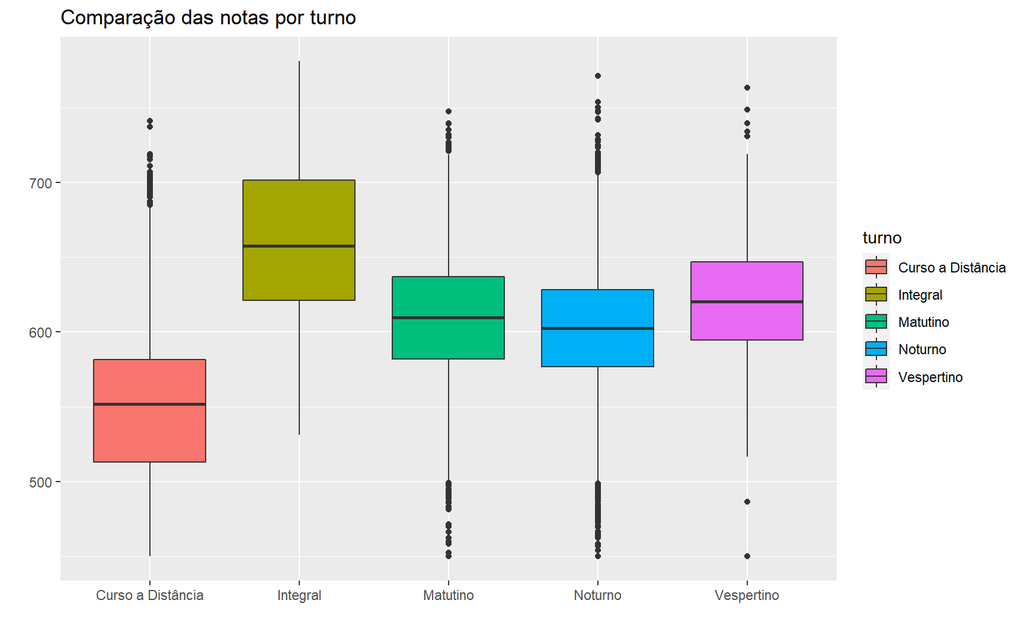

1. **Pelo gráfico, qual dos turnos possui a maior mediana das notas? Explique.**
2. **Qual a média e a mediana do turno identificado no item anterior?**
3. **Qual dos cinco turnos possui menor homegeneidade na nota integral ampla?**

`(Solução)`

1. Pelo gráfico, o turno que possui a maior mediana da notas é o **Integral**. Isso se deve ao fato de que, a mediana em um boxplot encontra-se destacada pelo segundo segmento de reta horizontal da “caixa” do boxplot. E, o turno **Integral**, a mediada é a maior (acima de 650), comparada às outras.
2. Sabemos que o turno em questão é o **Integral**. Portanto, vamos determinar a média e a mediana para esse turno. Para vamos seguir o caminho:
- selecionar as variáveis turno e nota (integral ampla);
- filtrar o turno integral;
- retirar os elementos não avaliados (NA)
- sumarizar com a média e a mediana.

O código abaixo traduz essas ideias:

```r
cursos %>%
  select(turno, nota_integral_ampla) %>%
  filter(turno == "Integral") %>%
  drop_na() %>%
  summarise(
    media_curso = mean(nota_integral_ampla),
    mediana_curso = median(nota_integral_ampla)
  )
```

| media_curso | mediana_curso |
| --- | --- |
| 663.1 | 657.5 |

Portanto, a média e a mediana são, respectivamente, 663.1 e 657.5 pontos.

3. Seguindo as ideias nas questões anteriores, vamos sumariar e verificar qual medida escolher.

```r
cursos %>%
  group_by(turno) %>%
  select(turno, nota_integral_ampla) %>%
  drop_na() %>%
  summarise(
    mediaCurso = mean(nota_integral_ampla), # média das notas
    dpCurso = sd(nota_integral_ampla),      # desvio padrão
    cvCurso = (dpCurso/mediaCurso) * 100    # coeficiente de variação
  ) %>%
  arrange(desc(cvCurso))
```

| turno | mediaCurso | dpCurso | cvCurso |
| --- | --- | --- | --- |
| Curso a Distância | 544.7927 | 53.24330 | 9.773131 |
| Integral | 663.1000 | 57.99986 | 8.746773 |
| Matutino | 609.1443 | 43.48318 | 7.138405 |
| Noturno | 601.8865 | 41.22816 | 6.849823 |
| Vespertino | 622.0320 | 40.98488 | 6.588870 |

Portanto, a menor homogeneidade (ou seja, maior variabilidde) é o turno “Curso a Distância”, pois possui o maior coeficiente de variação.

### Questão 08

**Qual a posição ocupa o estado da Bahia, no que se refere à frequência absoluta da variável `uf_busca`, disposta de forma decrescente?**

`(Solução)` Para sabermos a frequência absoluta, vamos criar uma distribuição de frequência, seguindo os seguintes passos:

- agrupar por `uf_busca`;
- selecionar essa mesma variável;
- retirar os NA’s;
- contar os elementos;
- arranjar de forma decrescente.

```r
cursos %>%
  group_by(uf_busca) %>%
  select(uf_busca) %>%
  drop_na() %>%
  count() %>%
  arrange(desc(n))
```

| uf_busca | n |
| --- | --- |
| SP | 11533 |
| MG | 4175 |
| PR | 3918 |
| RS | 3060 |
| BA | 2505 |
| SC | 2195 |
| RJ | 1442 |
| GO | 1278 |
| PA | 1201 |
| PE | 1148 |

[output cut: 17 more lines]

Fazendo uma inspeção simples, percebemos que a BA ocupa a 5º posição.

### Questão 09

**Quantos cursos foram identificados, distintamente, na variável `nome`?**

`(Solução)` A função `distinct()` é a nossa opção imediata; e, depois, `count()` para contar.

```r
cursos %>%
  distinct(nome) %>%
  count()
```

| n |
| --- |
| 296 |

Portanto, são 296 cursos distintos.

### Questão 10

**Apenas observando o gráfico abaixo, o que você pode concluir com respeito aos cursos exibidos, comparativamente? (cite, pelo menos, duas características gráficas).**

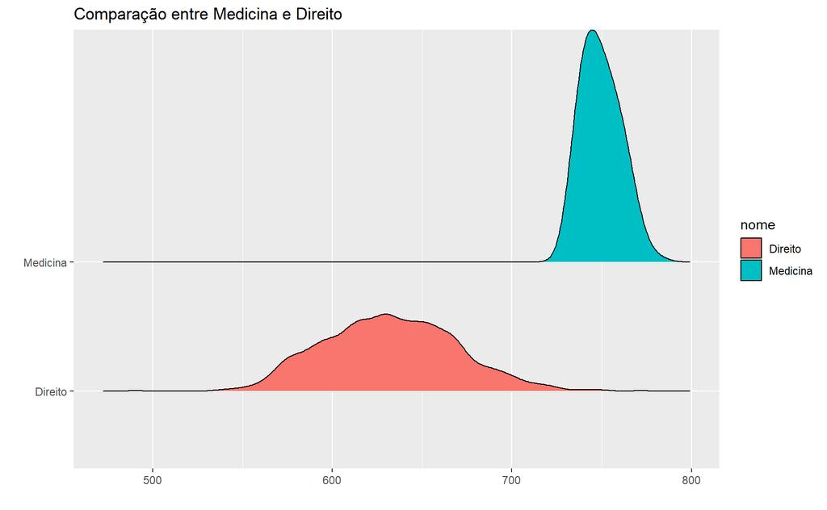

`(Solução)` O gráfico compara as notas de dois cursos: Medicina e Direito. Imediatamente, as características que mais saltam aos olhos são:

1. O curso de Medicina possui uma nota média **maior** do que o curso de Direito;
2. O curso de Medicina possui uma **maior** homogêneidade nas notas (todos muito próximos da média) do que o curso de Direito (há uma variação grande em relação à média).